# Taller comprimido: clasificación en política pública (ingreso y desigualdad)

# 1. Introducción

- Mismo ejercicio de clasificación, pero con una base claramente de **política pública**: el **Census Income** (microdatos del censo de EE.UU.).
- La tarea: predecir si una persona tiene un **ingreso alto** (más de 50.000 USD al año) a partir de características demográficas: edad, educación, ocupación, estado civil, horas trabajadas, etc.
- Es el dataset de referencia para estudiar **desigualdad**, **focalización de programas sociales** y, sobre todo, **equidad/sesgo algorítmico**: como incluye **raza** y **sexo**, es el caso clásico para discutir discriminación en modelos de decisión pública.
- Implementamos los cinco modelos sobre la misma base: kNN, Naive Bayes, SVM, árbol de decisión (C5.0) y Random Forest.

# 2. Datos

```r
install.packages(c("class", "e1071", "C50", "randomForest"))
```

- Los datos son públicos (UCI Machine Learning Repository). Así se obtienen (ya vienen incluidos en `data/census_income.csv`):

```r
url  <- "https://archive.ics.uci.edu/ml/machine-learning-databases/adult/adult.data"
cols <- c("age","workclass","fnlwgt","education","education_num","marital_status",
          "occupation","relationship","race","sex","capital_gain","capital_loss",
          "hours_per_week","native_country","income")
censo <- read.csv(url, header = FALSE, col.names = cols, strip.white = TRUE,
                  stringsAsFactors = TRUE, na.strings = "?")
write.csv(censo, "data/census_income.csv", row.names = FALSE)
```

- Cargamos el archivo, quitamos columnas poco útiles, eliminamos las filas con datos faltantes (“?”) y tomamos una muestra de 5000 (para que corra rápido en clase):

```r
censo <- read.csv("data/census_income.csv", strip.white = TRUE,
                  stringsAsFactors = TRUE, na.strings = "?")
censo$fnlwgt        <- NULL   # peso muestral del censo, no es un predictor
censo$education     <- NULL   # redundante con education_num
censo$native_country <- NULL  # 41 categorias, casi todo EE.UU.
censo <- censo[complete.cases(censo), ]   # quitar filas con "?"
set.seed(123)
censo <- censo[sample(nrow(censo), 5000), ]
censo$income <- factor(censo$income)      # objetivo: <=50K vs >50K
table(censo$income)
```

```
##
## <=50K  >50K
##  3834  1166
```

- Quedan 11 predictores (numéricos como edad y horas trabajadas; categóricos como ocupación y estado civil). Las clases están **desbalanceadas** (la mayoría gana <=50K): clave para la evaluación.

# 3. Partición entrenamiento / prueba

```r
set.seed(123)
idx <- sample(nrow(censo), 0.75 * nrow(censo))
entrena <- censo[idx, ]
prueba  <- censo[-idx, ]
verdad  <- prueba$income
```

# 4. k vecinos más cercanos (kNN)

- kNN se basa en **distancias**, así que necesita predictores **numéricos**. Convertimos las categóricas en variables **indicadoras** (0/1) con `model.matrix()` y normalizamos. (Los modelos de árboles no lo necesitan.)

```r
normalizar <- function(x) {
  rango <- max(x) - min(x)
  if (rango == 0) return(rep(0, length(x)))   # evita dividir por cero
  (x - min(x)) / rango
}
X <- model.matrix(income ~ . - 1, data = censo)   # categoricas -> indicadoras
X <- as.data.frame(lapply(as.data.frame(X), normalizar))
```

```r
library(class)
knn_pred <- knn(train = X[idx, ], test = X[-idx, ],
                cl = censo$income[idx], k = 63)    # k cercano a la raiz del n
mean(knn_pred == verdad)                       # precision
```

```
## [1] 0.8304
```

```r
table(Real = verdad, Prediccion = knn_pred)    # matriz de confusion
```

```
##        Prediccion
## Real    <=50K >50K
##   <=50K   895   71
##   >50K    141  143
```

- La **matriz de confusión** cruza la clase real con la predicha: la diagonal son los aciertos; fuera de ella, los errores.

# 5. Naive Bayes

```r
library(e1071)
nb_modelo <- naiveBayes(income ~ ., data = entrena)
nb_pred   <- predict(nb_modelo, prueba)
mean(nb_pred == verdad)
```

```
## [1] 0.8248
```

```r
table(Real = verdad, Prediccion = nb_pred)
```

```
##        Prediccion
## Real    <=50K >50K
##   <=50K   915   51
##   >50K    168  116
```

# 6. Support Vector Machine (SVM)

```r
svm_modelo <- svm(income ~ ., data = entrena, kernel = "radial")
svm_pred   <- predict(svm_modelo, prueba)
mean(svm_pred == verdad)
```

```
## [1] 0.8568
```

```r
table(Real = verdad, Prediccion = svm_pred)
```

```
##        Prediccion
## Real    <=50K >50K
##   <=50K   912   54
##   >50K    125  159
```

# 7. Árbol de decisión (C5.0)

```r
library(C50)
c5_modelo <- C5.0(income ~ ., data = entrena)
c5_pred   <- predict(c5_modelo, prueba)
mean(c5_pred == verdad)
```

```
## [1] 0.8496
```

```r
table(Real = verdad, Prediccion = c5_pred)
```

```
##        Prediccion
## Real    <=50K >50K
##   <=50K   890   76
##   >50K    112  172
```

- El árbol se puede **visualizar**. Cada nodo es una pregunta sobre un predictor (educación, estado civil, edad…):

[figure not shown]

```r
plot(c5_modelo)
```

# 8. Random Forest

```r
library(randomForest)
set.seed(123)
rf_modelo <- randomForest(income ~ ., data = entrena)
rf_pred   <- predict(rf_modelo, prueba)
mean(rf_pred == verdad)
```

```
## [1] 0.8648
```

```r
table(Real = verdad, Prediccion = rf_pred)
```

```
##        Prediccion
## Real    <=50K >50K
##   <=50K   897   69
##   >50K    100  184
```

- ¿Qué variables pesan más para predecir el ingreso alto?

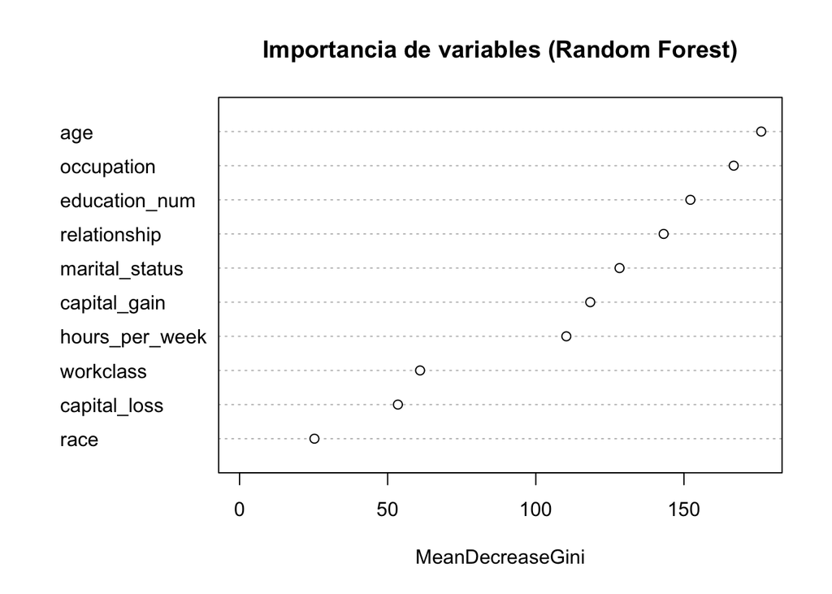

```r
varImpPlot(rf_modelo, n.var = 10,
           main = "Importancia de variables (Random Forest)")
```

# 9. Comparación

```r
precision <- c(
  kNN          = mean(knn_pred == verdad),
  NaiveBayes   = mean(nb_pred  == verdad),
  SVM          = mean(svm_pred == verdad),
  C5.0         = mean(c5_pred  == verdad),
  RandomForest = mean(rf_pred  == verdad)
)
round(sort(precision, decreasing = TRUE), 4)
```

```
## RandomForest          SVM         C5.0          kNN   NaiveBayes
##       0.8648       0.8568       0.8496       0.8304       0.8248
```

[figure not shown]

```r
barplot(sort(precision), horiz = TRUE, las = 1, xlim = c(0, 1),
        col = "seagreen", xlab = "Precisión",
        main = "Comparación de modelos (ingreso)")
```

- Dos lecciones de política pública:
  1. **El desbalance engaña**: como la mayoría gana <=50K, un modelo que prediga “todos <=50K” ya acierta ~76%. La precisión total no basta: hay que mirar la **matriz de confusión** y métricas como sensibilidad y kappa (**sesión 4**).
  2. **Equidad**: el modelo usa `race` y `sex` como predictores. ¿Es legítimo que una decisión pública dependa de ellos? Aquí es donde el *machine learning* se cruza con la **discriminación** y la **justicia algorítmica** — una discusión imprescindible al llevar estos modelos a la política.